# Mapping Btnl[1,4,6] Genes to Small Intestinal Epithelium scRNA-Seq Data: Haber *et. al.*

philip.east@crick.ac.uk

Compiled: 09 April, 2020 @ 15:08:17

```r
library( Seurat )
library( tidyverse )
set.seed( 1000 )
```

```r
my_grey <- "#707173"
my_red <- "#e3001a"
```

# Introduction

Presented here is a re-analysis of scRNA-Seq data from [Haber et. al.](https://www.nature.com/articles/nature24489) ‘A single-cell survey of the small intestinal epithelium’. Here we show the expression patterns of specific Btnl genes in different intestinal cell populations reported in Haber *et. al.*

# Btln Genes

We are interested in Btnl1/4/6.

```r
genes <- c( "Btnl1", "Btnl4", "Btnl6" )
```

# scRNA-Seq data

The raw data and processed cell sets can be found at GSE92332.

## Read in data

We read in the raw counts contained within [GSE92332_SalmHelm_UMIcounts.txt](https://www.ncbi.nlm.nih.gov/geo/download/?acc=GSE92332&format=file&file=GSE92332%5FSalmHelm%5FUMIcounts%2Etxt%2Egz). Cell barcode, cell type and infection status labels were obtained from column headers.

```r
sc_exprs_mat_file <- "GSE92332_SalmHelm_UMIcounts.txt"
dat <- read.delim( file = sc_exprs_mat_file )

design_l <- strsplit( colnames( dat ), "_" )
names( design_l ) <- unlist( lapply( design_l, function( x ) paste( x[ 2 ], x[ 1 ], sep = "_" ) ) )
design_df <- do.call( 'rbind', design_l ) %>%
    as.data.frame( )
colnames( design_df ) <- c( "cell_group", "barcode", "condition", "cell_type" )

colnames( dat ) <- rownames( design_df )
srat_obj <- CreateSeuratObject( counts = dat,
                               meta.data = design_df,
                               project = "haber_etal",
                               min.cells = 0,
                               min.features = 0 )

srat_obj@meta.data <- srat_obj@meta.data %>%
    rownames_to_column( var = "cell_id" ) %>%
    mutate( cell_id_tmp = cell_id ) %>%
    column_to_rownames( "cell_id_tmp" )
srat_obj
```

```
## An object of class Seurat
## 15215 features across 9842 samples within 1 assay
## Active assay: RNA (15215 features)
```

# QC

Here we check the number of genes and UMIs identified per cell. These were found to be within expected ranges.

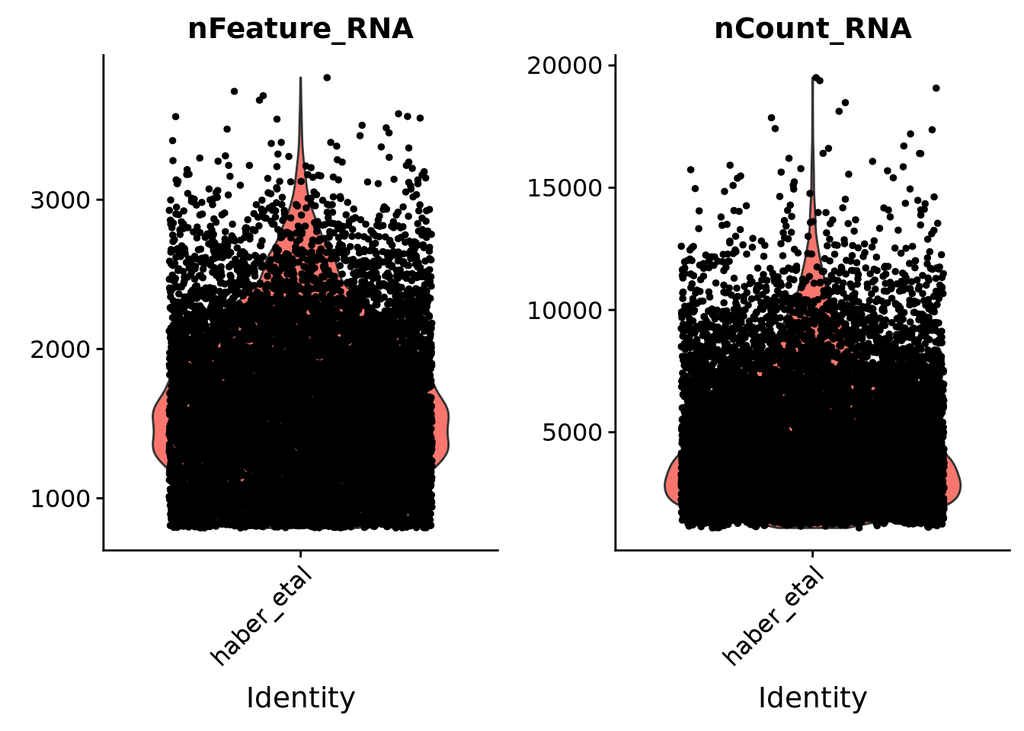

```r
VlnPlot( object = srat_obj,
        features = c("nFeature_RNA", "nCount_RNA" ),
        ncol = 2,
        slot = "counts" )
```

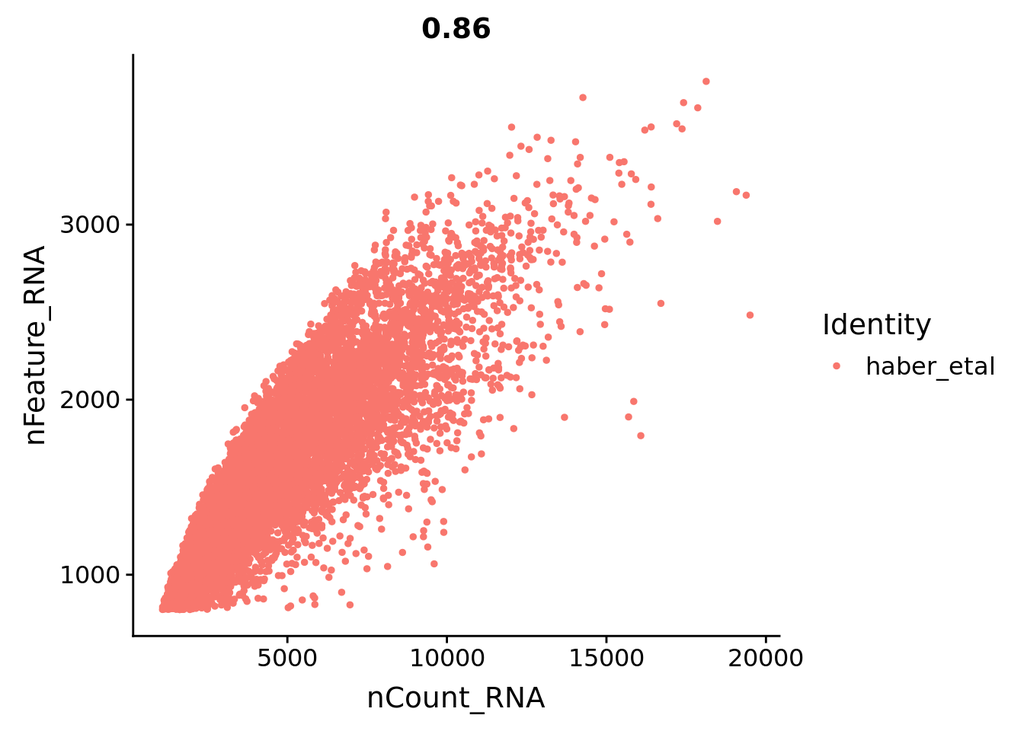

```r
plot1 <- FeatureScatter( object = srat_obj,
                         feature1 = "nCount_RNA",
                         feature2 = "nFeature_RNA" )
plot1
```

# Preprocess raw counts

Here we process the raw counts in-line with the standard Seurat workflow. We first normalise the raw counts by scaling them to 10,000 counts and applying a log transformation. We identify the 2000 most variable genes using Seurat’s vst method. We then scale the data prior to running PCA. The cells are then clustered and non-linear dimension reduction is applied using UMAP and the first 50 PCs.

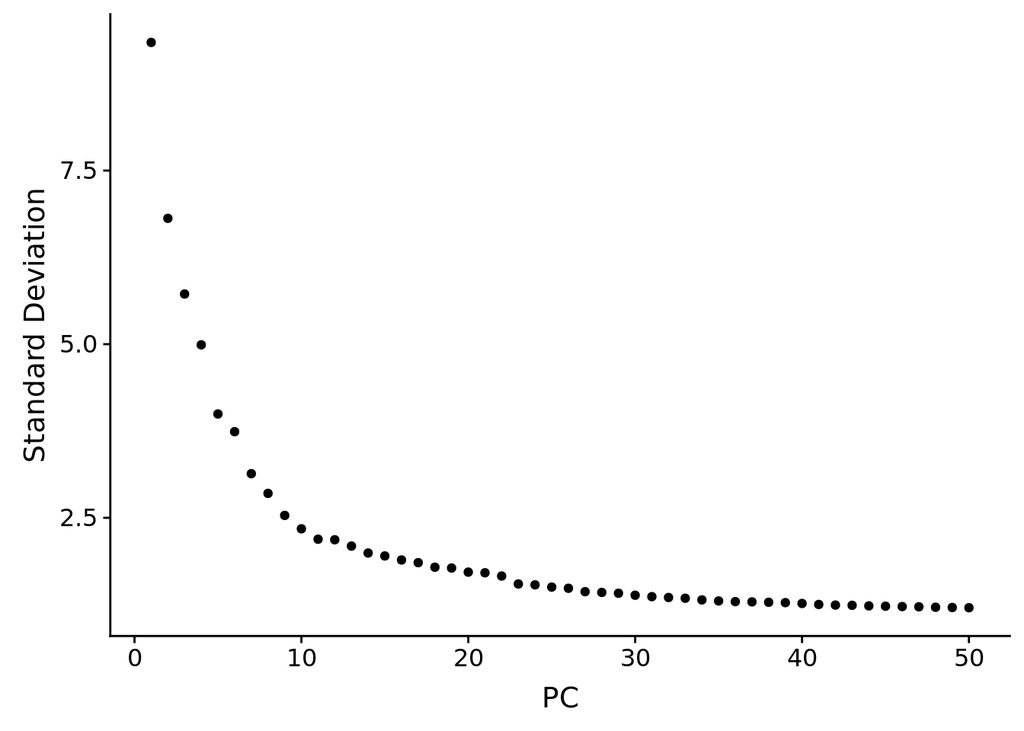

```r
dims_to_use <- 50
srat_obj <- NormalizeData( srat_obj, normalization.method = "LogNormalize", scale.factor = 10000 )
srat_obj <- FindVariableFeatures( object = srat_obj,
                                     selection.method = 'vst',
                                     nfeatures = 2000 )
srat_obj <- ScaleData( object = srat_obj, features = rownames(x = srat_obj ) )
srat_obj <- RunPCA( object = srat_obj, features = VariableFeatures( object = srat_obj ), verbose = FALSE )
ElbowPlot( object = srat_obj, ndims = 50 )
```

```r
srat_obj <- FindNeighbors( object = srat_obj, dims = 1:dims_to_use, verbose = FALSE )
srat_obj <- FindClusters( object = srat_obj, resolution = 0.5, verbose = FALSE )
srat_obj <- RunUMAP( object = srat_obj, dims = 1:dims_to_use )
```